# Sense checking understanding of the Prisons Team’s remand model

Brian Burton

03/05/2023

## Aim

To test how well our application of linear regression coefficients produces remand volumes that match those used by the prisons team.

## Method

The Courts team produce a version of their crown output file (as used by the Crown parts of prisonflowcast), which has a backlog adjusted to match HMCTS outstanding caseload. The calibrated backlog is used by the Prisons team to forecast demand by application of co-efficients from a linear regression.

We are using calibrated backlogs to forecast remand and test here that our approach produces remand forecasts similar to those provided by the Prisons team.

## Results

First, can we produce the same remand forecast when using the Prisons Team’s regression co-efficients? In the following we have applied co-efficients provided by the Prisons Team (See ‘20230503 - Charlotte Wallace - RE_ Gender split and remand ratio_.msg’) to backlog volumes provided by the Courts team (see 20230427 - Chun-yee Cheng - RE_ Latest Crown files_.msg).

The match is virtually exact, possibly within rounding error. The exception is the early period when the Prison Team they apply an additional ‘calibration’ to ensure a smooth transition from remand population in the historical period.

Although this graph does not rely on package functions, it proves that our interpretation of the co-efficients provided by the Prisons Team is correct.

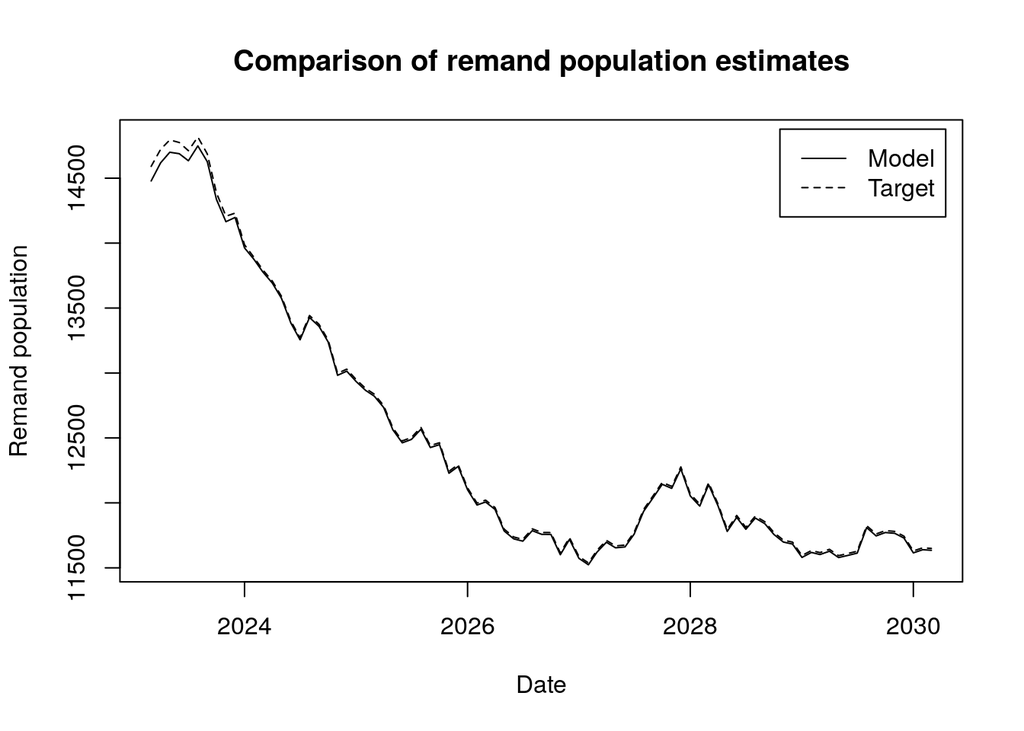